# Module 4, Lesson 2: Markdown

In this lesson, we were introduced to the `rmarkdown` package for creating and sharing documents. R Markdown is a seamless way to combine R code with interpretation all within one document – all of the independent guides in this course were written with R Markdown!

This independent guide will not go through all of the content from the guided practice. Rather, it will cover a few key steps to get you started on your first R Markdown document. At the end, we point you to a “cheatsheet” for referencing basic (and not-so-basic) commands with R Markdown.

## Your first markdown

To create an R Markdown document, go to File > New File > R Markdown…

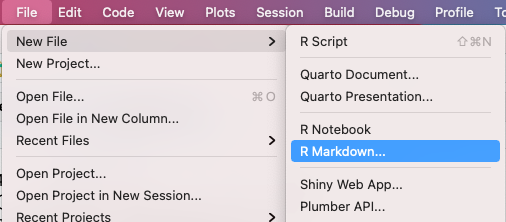

**Image description: Creating a R Markdown document**

If this is the very first time creating an R Markdown document on your computer, or if you are working on rstudio.cloud, you will likely get a prompt that says you need to first install some missing R packages, the most relevant of which is called `rmarkdown`:

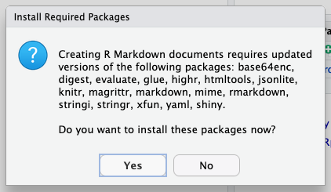

**Image description: Prompt to install necessary R packages for using R Markdown**

As long you work on this computer, you will not need to re-install these packages in the future. In fact, you won’t even need to *load* them in the future. That will all be taken care of in the background.

After installation is complete, you will see a window asking you to provide basic information for your document – title, name, and date – and also the type of document you want to create:

[figure not shown]

**Image description: Initial configuration of your R Markdown document**

Your choices are not permanent – they can be modified and updated later.

Choose **HTML** as the output format (not PDF, as we did in the guided practice), and then press ‘OK’ to create the document.

## Navigating an .Rmd document

Now, a tab should be on your RStudio application, containing an R Markdown (.Rmd) document that is pre-filled with content. This approach is intended as a scaffold for new learners: immediately you get to see working examples of the different elements of an R Markdown document, and then you can change the actual content for your purposes. Eventually, you will presumably want to delete this pre-filled content.

The first thing to do is *knit* the document into its final form. This will allow you to visualize how the components in the .Rmd file affect the final output. To knit the document, look for a needle-and-thread symbol at the top of the page, next to the word ‘Knit’. Press it now. After being prompted to save the .Rmd file, a new page should pop up in front of you, displaying the knitted final output. Since we chose HTML as the output, this will be an .html file. It is saved in the same directory as the .Rmd file. Toggle between the .Rmd file in RStudio and the knitted output to help you begin to see the connections between the two files. Notice, for example, that when a word(s) is bordered by two asterisks on either side, i.e. **Knit**, the knitted document renders that word(s) in boldface font: **Knit**.

### Header

Now go back to the .Rmd file. At the very top is the header, where you can modify the title, the author, the date, and the output format:

```r
---
title: "First markdown document"
author: "Health DS Learner"
date: "2022-06-15"
output: html_document
---
```

Change the contents of the title, author, or date and re-knit the document. It doesn’t matter what you change, just notice that the top of the re-knitted document reflects whatever change you made. If you don’t want a title, author, or date printed at the top, you can replace the quoted string with `""` (empty quotes).

### R chunks

In an .R script, R assumes by default that what you type is meant to be interpreted as R code, and if you want to write prose, e.g. an English language comment, you need to preface what you write with `#` (otherwise you’ll get an error). In contrast, in an .Rmd file, R assumes by default that what you write is meant to be interpreted as prose, and so you need a special demarcation to indicate what *should* be interpreted as R code. That demarcation is called an R chunk: the chunk starts with three backticks followed by curly braces around the letter r, and the chunk ends with three more backticks:

````r
```{r}
# this is an R chunk. put R code here
# it can be as many lines as you need
library(tidyverse)
library(healthds)
```
````

Think of chunks as miniature R scripts. When you knit the document, then when R encounters a chunk, it will run the contents inside as if it were R code. In your .Rmd file, there are already code chunks, the first of which spans lines 8-10 and looks like this:

````r
```{r setup, include=FALSE}
knitr::opts_chunk$set(echo = TRUE)
```
````

Copy and paste just the two `library` commands into that existing chunk. at this point you’re not creating a new chunk but just making an existing one bigger. Your final revised chunk should look like this:

````r
```{r setup, include=FALSE}
knitr::opts_chunk$set(echo = TRUE)
library(tidyverse)
library(healthds)
```
````

If you have multiple chunks in a document, they are evaluated chronologically based upon the order they appear in the file, meaning that the results from an early chunk can be referenced and used by a later chunk. So, for example, I can use functions from the `tidyverse` and `healthds` packages because I loaded them in the chunk above:

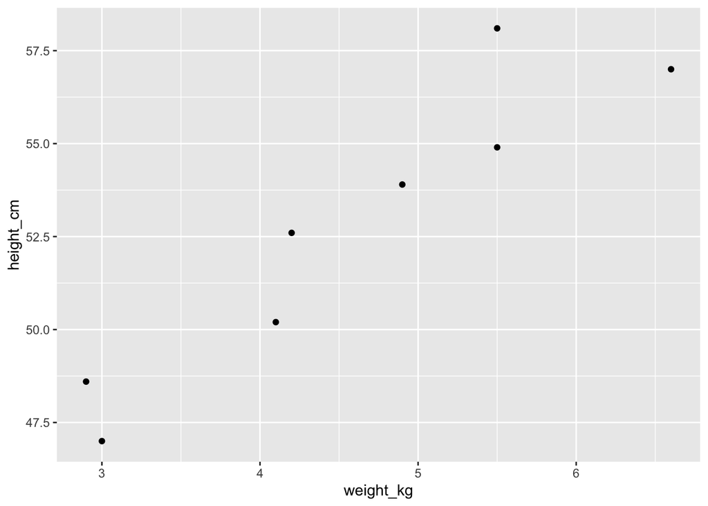

````r
```{r}
ggplot(growth_data) +
  geom_point(aes(x = weight_kg, y = height_cm))
```
````

In your document, there is the following chunk:

````r
```{r}
summary(cars)
```
````

Replace that chunk with the chunk we wrote just above and re-knit the document.

Chunks have options to control whether and how they are displayed and evaluated. Chunk options appear as comma-separated arguments after the letter `r` inside the curly braces. For example, if you want to run R code but don’t want your readers to see the actual code, e.g. you want to show just the plot itself, you use would use set `echo = FALSE`:

````r
```{r, echo = FALSE}
ggplot(growth_data) +
  geom_point(aes(x = weight_kg, y = height_cm))
```
````

Normally, R “echos” your code chunk back to you, but by setting `echo = FALSE`, we are turning off this behavior. Another common chunk option is `eval = FALSE`, which means that the chunk won’t be evaluated. So, if your chunk is this:

````r
```{r, eval = FALSE}
ggplot(growth_data) +
  geom_point(aes(x = weight_kg, y = height_cm))
```
````

then the output in the knitted document will be this:

```r
ggplot(growth_data) +
  geom_point(aes(x = weight_kg, y = height_cm))
```

This is useful to demonstrate code concepts without actually executing the code itself. Try adding `echo = FALSE` to your own chunk.

Other options are `include = FALSE` (which means run the code but don’t echo the code *and* don’t print any of the output in the output) and `message = FALSE` (which suppresses the printing of any informational messages in the output).

### Tables

You can print tables just as they would appear in RStudio:

````r
```{r}
growth_data
```
````

```
## # A tibble: 8 × 4
##   id    months weight_kg height_cm
##   <chr>  <dbl>     <dbl>     <dbl>
## 1 001        0       3        47
## 2 001        1       4.1      50.2
## 3 001        2       4.9      53.9
## 4 001        3       5.5      58.1
## 5 002        0       2.9      48.6
## 6 002        1       4.2      52.6
## 7 002        2       5.5      54.9
## 8 002        3       6.6      57
```

Alternatively, you can use the `knitr` package to format your tables nicely:

````r
```{r, echo = FALSE}
library(knitr)
kable(growth_data)
```
````

| id | months | weight_kg | height_cm |
| --- | --- | --- | --- |
| 001 | 0 | 3.0 | 47.0 |
| 001 | 1 | 4.1 | 50.2 |
| 001 | 2 | 4.9 | 53.9 |
| 001 | 3 | 5.5 | 58.1 |
| 002 | 0 | 2.9 | 48.6 |
| 002 | 1 | 4.2 | 52.6 |
| 002 | 2 | 5.5 | 54.9 |
| 002 | 3 | 6.6 | 57.0 |

The `kable` function makes your resulting tables much “friendlier” to read, especially for non-R users. Note that in my code chunk above, I’m suppressing echoing of the code chunk, so that it won’t actually get printed in the final compiled document. Copy and paste this R chunk into your own R Markdown document, and re-knit the result.

### Choosing output format

```r
install.packages('tinytex')
tinytex::install_tinytex()  # install TinyTeX
```

You only need to run the above two lines of code *once*. Doing so will download and install files onto your computer that will allow R to knit an R Markdown document to a PDF. Having done so, you can now change header of your R Markdown file so that it looks like this:

```r
---
title: "First markdown document"
author: "Health DS Learner"
date: "2022-06-15"
output: pdf_document
---
```

Re-knitting the document after having made this change, you will get a PDF instead of HTML file.

### Cheatsheet

R Markdown offers a great deal more than what we are able to cover here. On the Coursera page is a cheat sheet specifically for R Markdown that is produced by the RStudio company (note: in November 2022, the RStudio company official changed its name to Posit). You can also find it here: https://raw.githubusercontent.com/rstudio/cheatsheets/main/rmarkdown-2.0.pdf This cheatsheet covers everything we’ve done here plus much much more.